# Izzy’s Walking logs

## Distribution of Walk Duration

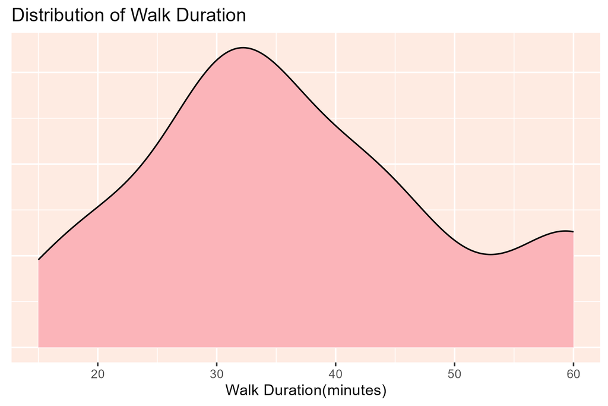

This plot shows the distribution of Izzy’s walk durations.  
The average walk time was approximately **35 minutes**, and most walks lasted between 30 and 40 minutes.  
The smooth curve helps reveal a consistent daily routine.

## Whether Izzy met other dogs

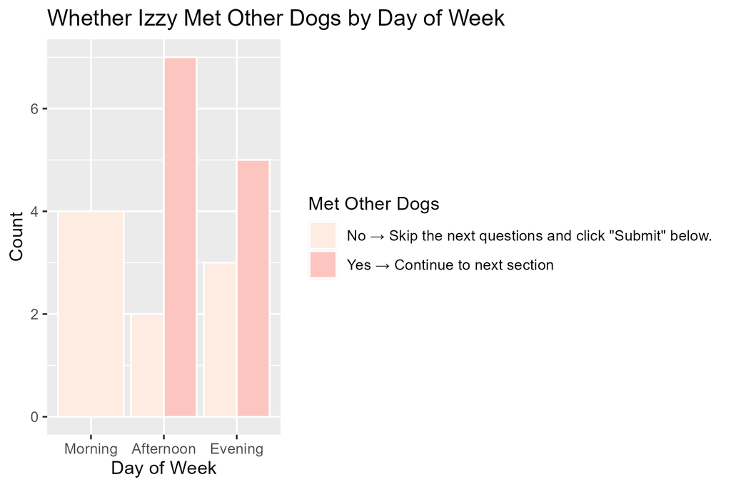

## Dog sizes met by day

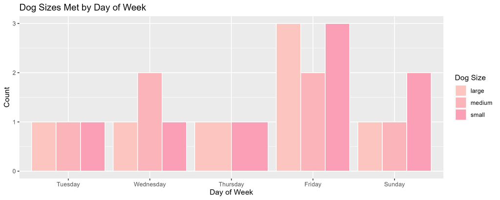

This visualisation shows the sizes of dogs Izzy met on each day of the week.  
While **Friday** had the highest total number of dog encounters across all sizes, there wasn’t a strong pattern of one dog size dominating overall.  
**Small dogs** were frequently encountered, especially on Friday and Sunday, but **large** and **medium** dogs also appeared consistently across multiple days.  
I used `str_detect()` from the `stringr` package to extract size information from text entries, and `separate_rows()` to handle multiple sizes reported in a single observation.